# Dissertation First Draft

190005680

2022-10-10

# 1 Introduction

# 2 What is Functional Data?

To answer this question let’s first think about what type of data a statistician is typically tasked with analysing and how this data would be given to the statistician. Let us take an example of a survey where patients are given a drug thought to reduce blood pressure. In this example, the statistician is given blood pressure readings for each patient on the first 4 days after the patient has taken the drug. These readings would typically be stored in a some form of data frame. This data frame could then be converted to a data matrix such that each column of the matrix represented a new patient and each row represented a new day on which readings were taken. An example of such a data matrix (with fabricated data) is given in (2.1) below.

$$\begin{equation}
\begin{pmatrix}
142 & 155 & 136\\
131 & 134 & 122\\
122 & 120 & 110\\
95 & 111 & 99
\end{pmatrix}
\tag{2.1}
\end{equation}$$

In this data matrix the first entry given in the top left represents patient 1’s blood pressure reading (in mmHg) on day 1 after taking the drug, the entry directly below represents patients 1’s blood pressure reading on day 2 and so on.

Returning to the previous example imagine that a persons blood pressure could be taken at any time the statistician requested such that any time within the survey period of 4 days was accessible. This would not be practically achievable as the statistician may ask to have the persons blood pressure read multiple times within the same minute for example. However, if the relationship between time and a patients blood pressure was able to be given by a function with which the statistician could input a point in time within the 4 days and the patients blood pressure would be output then the statistician could do this. Following from this, the statisticians sample would now no longer consist of blood pressure readings at various times for each patient. It would instead consist of 3 functions, one for each patient, which give the relationship each patients blood pressure has with the time since the drug was taken. Assuming that such a function could be found, that would mean that if the observed values given in the data matrix shown in (2.1) were free from error they would simply be draws from this set of functions for each patient. Assuming these functions could be found we could then consider these functions to be the statisticians new sample of observations which changes the statisticians sample from consisting of data points to instead being a sample of functions. This new sample of functions is called functional data.

This change can also be thought of as expanding the data matrix to now be infinitely dimensional e.g. every point in an infinetly discretised sample of continuous time has an associated row in the data matrix. This expansion makes some theoretical sense as a function is a 1-1 mapping of points in the domain of the function (the input values) to values in the range of the function (the values output by the function). This clearly makes little practical sense as storing infinitely dimensional data matrices is impossible. However, thinking of our samples this way does show some of the advantages that functional data analysis holds over other more conventional forms of data analysis.

# 3 Advantages of Functional Data

The consideration of the functional data as effectively being an infinitely dimensional data matrix shows a clear advantage of working with functional data over non-functional. This advantage is that it is a potential remedy to the so-called ‘Curse of Dimensionality’ (Riccio (2022)). This refers to the issue that as the number of dimensions of a dataset increases (be that the number of variables collected for each unit within a study or the number of times that variable is collected within the course of the study) the computational power needed to analyse the dataset grows exponentially. Functional data analysis allows a statistician to not work with large matrices of data but instead with functions for which there are standard mathematical approaches which are more computationally simplistic. High-dimensional data can also lead to over fitting of models to the data which reduces the predictive power of models. Functional data overcomes this issue by simplifying relationships between variables earlier on in the analysis which combats over fitting in the early stages of an analysis.

There is a clear issue with this discussion being that functional data is impossible to have access to in a practical setting. A statistician can only have access to a finite amount of readings of quantities and the relationship between a quantity and time is typically not known otherwise statistical techniques would not have to be used to assess these relationships. In practical applications of functional data analysis the functional data must be estimated from the information that a statistician has access to, being measurements of a certain quantity for several time points. The Creating a Functional Variable section will detail how these functions are estimated from data.

# 4 Creating a Functional Variable

## 4.1 How is Observed Data Related To Functional Data?

As discussed previously, if a statistician wants to work with functional data they must estimate these functions from their observed data (which is collections of observations of a quantity over time for several replications). Therefore, there must be a relationship assumed between the functional data and the observed data.

Within this dissertation it will be assumed that the value of the variable of interest that is observed at a certain time $t_0$ is the value of the function which describes this variables relationship with time evaluated at $t_0$ with some normally distributed error in the observation. This relationship is better given by Equation (4.1).

$$\begin{equation}
Y_i = f(t_i) + \epsilon_i
\tag{4.1}
\end{equation}$$

where $Y_i$ is the value of the variable of interest at time $t_i$ and $\epsilon_i \sim N(0,\sigma^2)$ ($\sigma$ is a constant).

In order to estimate a functional sample from observed data a process called smoothing must be used. A new example is established in the Basis Functions section which easily displays how a statistician would use this process to estimate a functional sample from a non-functional sample

## 4.2 Basis Functions

In order to give the reader an understanding of how to create a functional data object (one function which describes the relationship between a variable and time), both mathematically and in computationally in R, a new example will be used. In this example, it is assumed that the relationship between a variable and time is already known. This variable Y is related to time by the functional relationship given in Equation (4.2). This relationship is relatively simple and is expressible through typical mathematical notation (non-analytic/non-solvable). The reader should not that this will not typically be the case for relationships between variables and time. In fact, it is generally not possible to attain a simply expressible function for this relationship.

$$\begin{equation}
Y(t)=f_1(t)=\frac{1}{300}(t^3+t+e^{-t^2})
\tag{4.2}
\end{equation}$$

```r
set.seed(190005680)

function_ex_1 <- function(Time){
  1/300*(Time+Time^3+exp(-Time^2))
}

sigma_2_errors <- 30

Time_Grid <- seq(-40,40,1)

Observations <- function_ex_1(Time_Grid)

Number_Of_Observations <- length(Observations)

Observation_Errors <- rnorm(Number_Of_Observations,0,sigma_2_errors)

ex_1_data <- data.frame(
  Time = Time_Grid,
  Y=Observations+Observation_Errors
)
```

The simulated data is shown graphically in Figure 4.1 below.

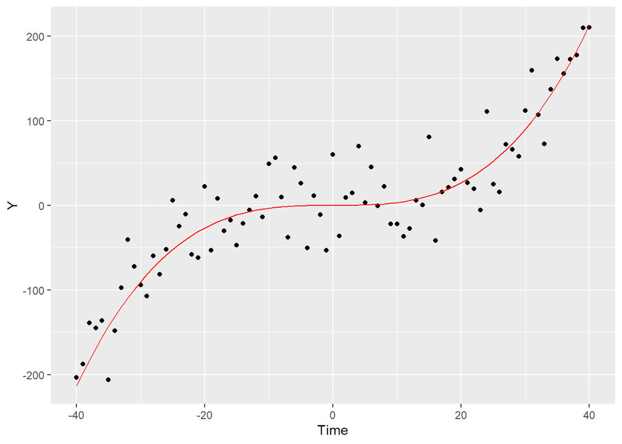

In order to estimate the original function, $f_1(t)$, from this new dataset we need to find some building blocks with which we can constuct this function from the ground up. When working with vectors, basis vectors, sets of vectors that can be linearly combined to  
construct any vectors within a defined vector space, can be thought of as the building blocks for all vectors. Similarly, basis functions can be thought of as the building blocks of all functions.

Basis functions are sets of functions which can be linearly combined to produce any function within the function space they belong to. Basis functions are very powerful tools for function estimation and are often used to define functions from sets of points in space. This dissertation will work with two sets of basis functions, the Fourier Basis and the B-Spline Basis which are both sets of functions which can be used to represent all functions with a domain in $[t_0,t_1]$ where $t_0$ and $t_1$ are arbitary.

We have just established that a linear combination of the basis functions we will be working with can represent any function with domain in $[t_0,t_1]$. Therefore, we can represent our function $f_1$ as a linear combination of these basis functions. This expansion is shown in Equation (4.3).

$$\begin{equation}
Y(t) = f_1(t)\approx\sum_{k=1}^K{c_k\phi_k(t)} = \boldsymbol{c'\phi}(t) \; \;\; t \in [t_0,t_1]
\tag{4.3}
\end{equation}$$

where $c_k$ is the coefficient of the $k_{th}$ basis function $\phi_k(t)$ and $\{\phi_k(t):k\in\mathbb{Z}^+\}$ is a set of basis functions for the set of all functions with domain in $[t_0,t_1]$.

$\boldsymbol{\phi}(t)$ is a vector of the basis functions used to construct $f_1(t)$ evaluated at time $t$ and $\boldsymbol{c}$ is a vector of coefficients for each of these basis functions.

It was mentioned that this dissertation will use the Fourier Basis and the B-Spline basis. These will be defined in the The Fourier Basis and The B-Spline Basis sections respectively.

### 4.2.1 The Fourier Basis

The Fourier Basis

The Fourier basis system is defined such that:

$$\begin{align*}
\phi_1(t)&=1 \\
\phi_2(t)&=sin(\omega t) \\
\phi_3(t)&=cos(\omega t) \\
..&.. \\
\phi_{2n}(t)&=sin(n \omega t) \\
\phi_{2n+1}(t)&=cos(n \omega t)
\end{align*}$$

where $n \in \mathbb{Z}$ and $t \in \mathbb{R}$.

These functions repeat themselves over a period $T$. The parameter $\omega$ featured in these function is defined in relation to the period $T$ such that:

$$\omega=2\pi/T$$

To create a Fourier basis system in R the create.fourier.basis command in the fda R package is used. An example is given below:

```r
create.fourier.basis(c(45,65),65,5)
```

This will create a series of 65 fourier basis functions $\phi_i(t)$ with $i=1,...,65$ over the interval of $t \in[45,65]$ with a period of $T=5$. The basis function must always come in a sin cos pair e.g if $\phi_2(t)=sin(\omega t)$ is included then $\phi_3(t)=cos(\omega t)$ must also be included. The function create.fourier.basis accommodates for this, so that if an even number of basis function (K) is requested (there should always be an odd number) the function will also include that basis functions cosine pair (effectively making the number of output basis functions K+1). The fourier basis is useful for data which is periodic in nature for example air temperature over the course of a few days, as the temperature may follow similar trends each day (so period $T=1\; day$ ) or the angle a lever is in relation to being upright over time (data using angles is a very common usage of a Fourier basis system in functional data analysis).

### 4.2.2 The B-Spline Basis

In order to explain what a B-spline basis is and how it is defined the reader must first understand what a spline basis in general is. Spline basis functions are piece-wise polynomial functions defined by the range they are defined over, their knots and their order.

To demonstrate the meaning of these terms we will look at the B-spline basis function. B-spline basis functions are defined by a recursion relation. This recursion relation states that for a B-Spline of order K+1, notated by $N_{i,k+1}(x)$ with *knot vector* $U=\{t_0,..,t_k\}$ is defined by :

$$N_{i,k+1}(x)=\omega_{i,k}(x)N_{i,k}(x)+(1-\omega_{i+1,k}(x))N_{i+1,k}(x)$$
where:
$$N_{i,1}(x) =
\begin{cases}
1 & if \; \;x \in [t_i,t_{i+1})\\
0 & elsewhere
\end{cases}$$
and :

$$\omega_{i,k}(x) =
\begin{cases}
\frac{x-t_i}{t_{i+k}-t_i} & where \; \;t_{i+k} \neq t_i \; and \; t_{i+k} \in U\\
0 & elsewhere
\end{cases}$$

This recursion relation can be quite difficult to understand for someone unfamiliar with B-spline basis and therefore a worked through example of finding some B-spline functions of order 2 can be found in the appendix of this paper.

There are a few key features of B-splines that are notable. One of these features is that the first and last spline must equal 1 at the boundaries (the first and last knot value). This is because at any points in the domain established by the knots the sum of all the B-splines is equal to 1 such that $\sum_{i=1}^KN_{i,k} = 1$. This feature of B-splines means that when a linear combination of these is taken the coefficient of any B-spline function is approximately equal to the value of the B-spline at it’s peak. Due to the first and last spline being equal to exactly one at the boundaries the coefficient of these splines is exactly equal to the value of these functions at their peak. Another feature is the relation between the number of knots, the order and number of basis functions. This relation is given by the following:

$$\begin{equation}
number \; of \; basis \; functions \; = \; order \; + \; number \; of \; interior \; knots
\tag{4.4}
\end{equation}$$

For example in the case given in the appendix where the order of splines we were looking for was order 2 and the number of interior knots we wanted to use was 2 then the number of basis functions in the basis system was 4.

To render B-spline basis functions in R for use in FDA functions we need to use the create.bspline.basis function from the FDA package. To render the basis system specified in the example given in the appendix we would use the command:

```r
create.bspline.basis(c(0,4),norder=2,breaks=c(0,1,3,4))
```

The first argument passed to this function gives the range that the spline basis should be defined over, the second argument defines the order of splines we wish to render and the final argument gives the values that knots should be placed at. The default specifications of this function allow for the user not to specify the knots. For example a call to the function that looks like this:

```r
create.bspline.basis(c(0,10),16,7)
```

There are many more spline basis possible for use in creating a functional data object such as M-splines, I splines and truncated power functions that are not discussed in the paper. I have chosen to discuss only B-splines and fourier series as potential basis functions as linear combinations of each are able to be used to estimate most functions with combinations of fourier series functions being used to estimate periodic functions and combinations of B-spline basis being used to estimate non-periodic functions. Our data from our example is non-periodic so we would wish to choose B-splines to fit our data.

A question that arises in relation to our example data is how we choose the order of B-spline that we need. The answer to this questions depends on what we are needing to do with our functional data object. If we are in need of it’s derivatives then the general rule is to *fix the order of the B-spline basis to be at least two higher than the highest order derivative that is needed*. It will become clearer in later chapters what orders of derivative are needed for certain types of analysis but for this example we are just trying to fit a simple functional data object and therefore do not need any derivatives. The general rule for this case is that cubic B-splines provide a smooth enough fit and so we will fix our order to be 4 for this example. The last thing to consider in relation to choosing our basis system for this example (and more generally) is how many functions we will need to create a smooth enough fit to the data. When using B-splines it is good if possible to place a knot at each observation value for your data set. For example if you have a data set that gives the number of leaves on a tree each year and you have data for 35 years you would want to put a knot at every year that you have an observation, giving you 35 knots in total and 33 internal knots.The number of basis functions, by relation (4.4), needed would therefore be 33 + order of B-spline basis function required. This is generally the most desirable knot placement, however there will be many examples that have too many data points.

To recap what we have just discussed, basis functions are functions that can be linearly combined to estimate more complex functions. There are two types of basis function most commonly used in creating functional parameters, these being fourier series basis functions, which fit repeating or periodic functions best,and B-splines, used to fit non-periodic functions.

Remembering that we are estimating $f(X)$ using the basis functions by the relation given in Equation (4.3) we still need to find our coefficients given in the coefficient vector $\boldsymbol{c}$.

## 4.3 Finding Coefficients

When finding these coefficients there are many considerations that must be made with regard to how we wish the curve to fit to our observed data. For example, we may want a curve that definitely passes through every observed value of our response variable (in our case $Y$) or we may want a smoother curve that gets close to all of our observed points while allowing for some observation error. The process of fitting a curve to the noisy observed data is called smoothing. This is because the choice of basis functions and coefficients can affect the ‘roughness’ of the fitted curve, where roughness refers to the level of over fitting the function has to the observed data.

### 4.3.1 Regression Smoothing

The first method of finding these coefficients that we will consider is smoothing using regression analysis. All methods discussed in this section can be applied for any choice of basis function.

This method of finding the coefficients uses the sum of squared error of the data which is given by:

$$\begin{equation}
SSE(\boldsymbol{x})=\sum_{j=1}^n{[y_j-x_(t_j)]^2}
\tag{4.5}
\end{equation}$$

where $y_j \;for\; j=1,..,n$ are the $n$ observed observation and the $x(t_j)$ is our estimated curve that is fit to the data evaluated at $t_j$, the explanatory variable associated with the observed value of $y_j$.

This SSE can be rewritten in terms of the coefficients such that:

$$\begin{equation}
SSE(\boldsymbol{c})=\sum_{j=1}^n{[y_j-\sum_{k=1}^K{c_k\phi_k(t_j)}]^2}= \sum_{j=1}^n{[y_j-\phi(t_j)'\boldsymbol{c}]^2}
\end{equation}$$
The vector $\phi(t_j)$ gives the value of each of the basis functions evaluated at the observed value $t_j$ of the response variable. All of the values of the basis functions evaluated at all of the observed values of the explanatory variable are stored in a matrix $\boldsymbol{\phi}$ (often called the basis matrix). They are stored such that each column of the matrix contains the basis functions evaluated at 1 observation of $t$, $t_j$. Therefore, we end up with a n by K matrix. In the example we have been looking at the $t_j$’s are our observed X values given in the matrix *ex_1_data*. To get our $\phi$ matrix we wish to evaluate our basis functions at all our observed X values. The function *eval.basis* given in the FDA package gives us our $\phi$ matrix with the inputs being our observed values of the explanatory variables and our basis.

```r
eval.basis(ex_1_data$X,basis_ex_1)
```

In this example, we can treat our functional matrix $\boldsymbol{\phi}$ similar to the $X$ matrix used in regression analysis where:

$$\begin{equation}
\boldsymbol{Y}= \boldsymbol{Xc}+\boldsymbol{\epsilon}
\end{equation}$$

where $\boldsymbol{Y}$ is a vector of observed response values, $\boldsymbol{X}$ is a matrix of explanatory values, $\boldsymbol{c}$ is a vector of coefficients and $\boldsymbol{\epsilon}$ is a vector of errors in the observations.

In regression analysis, the estimate of $\boldsymbol{c}$ that minimizes the SSE is given by:

$$\begin{equation}
\boldsymbol{\hat{c}}= (\boldsymbol{X'X})^{-1}\boldsymbol{X}'\boldsymbol{Y}
\end{equation}$$

When minimizing the SSE for finding the functional coefficients the estimate of the coefficients of the basis functions that minimizes the SSE is given by:

$$\begin{equation}
\boldsymbol{\hat{c}}= (\boldsymbol{\phi'\phi})^{-1}\boldsymbol{\phi'}\boldsymbol{Y}
\end{equation}$$

The FDA package has a function that can carry out this calculation for us. We need to give it our basis matrix, $\boldsymbol{\phi}$ and our vector of observed values $\boldsymbol{Y}$ and it will output our coefficient vector.

```r
phi_mat_ex_1 <- eval.basis(evalarg=ex_1_data$X,basisobj=basis_ex_1)

lsfit(phi_mat_ex_1,ex_1_data$Y,intercept = FALSE)$coef
```

These functions are not commonly used, however, as there is a function called *smooth.basis* which carries out the process laid out previously using these functions and outputs an already fitted functional data object. To get this function to determine the functional data observations coefficients such that they minimize the SSE we pass the function our vector of observed explanatory variable observations, generally given by $\boldsymbol{t}$ and in our case given by $X$, our vector of observed values, generally referred to as $\boldsymbol{Y}$, and the basis functions we wish to use to fit the functional data object.

```
## [1] "done"
```

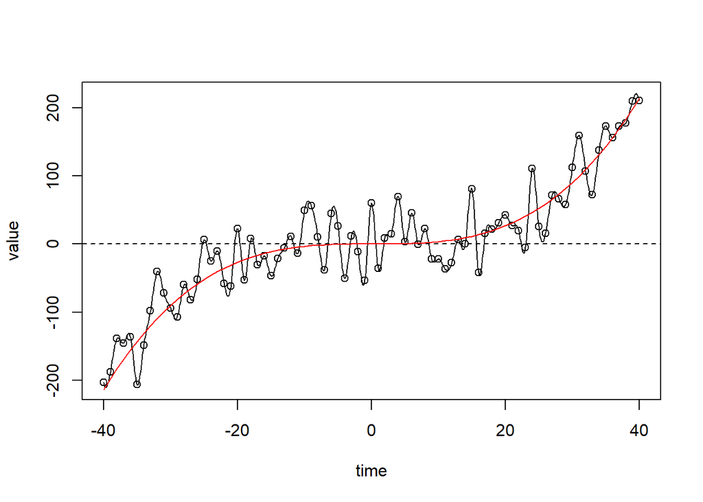

A plot of the fit of this functional data object fit using regression is given below.

This method of finding the coefficients of a functional data object has a few drawbacks. This method does not adjust for how smooth we wish our curve to be and tends to over fit the data if there are significantly more basis functions than data points. This method also tends to give very unstable estimates of the derivatives of the curves near the boundaries of our data which is nit useful as one of the main advantages of functional data analysis is that it allows for analysis of the derivatives of the functional aspects of the data.

### 4.3.2 Smoothing using a Roughness Penalty

$$F(\boldsymbol{c})=\sum_j[y_j-x(t_j)]^2+\lambda\int_{t_0}^{t_1}[Lx(t)]^2dt$$

$$F(\boldsymbol{c})=\sum_j[y_j-\boldsymbol{c'\phi}(t_j)]^2+\lambda\boldsymbol{c'}\boldsymbol{c}\int_{t_0}^{t_1}[L\boldsymbol{\phi}(t)L\boldsymbol{\phi}'(t)]dt$$

There are two unknowns in $F(\boldsymbol{c})$ those being our linear differential operator $L$ and our smoothing parameter $\lambda$ and these are chosen based on what features we wish our functional data object to have.

#### 4.3.2.2 Choosing an Appropriate Smoothing Parameter $\lambda$

The generalized cross-validation (GCV) cruteria was developed by Craven P. and G. Wahba to assist in finding the most appropriate value of $\lambda$ to use in smoothing using a roughness penalty.

The GCV for a particular functional data object is defined as shown in Equation (4.6) :

$$\begin{equation}
GCV(\lambda)=(\frac{n}{n-df(\lambda)})(\frac{SSE}{n-df(\lambda)})
\tag{4.6}
\end{equation}$$

The value of $\lambda$ that gives the lowest GCV is the most preferable. The GCV produced by a certain value of $\lambda$ can be found by accessing the GCV argument of a functional data object in R. An example of how to do this for our example is shown below.

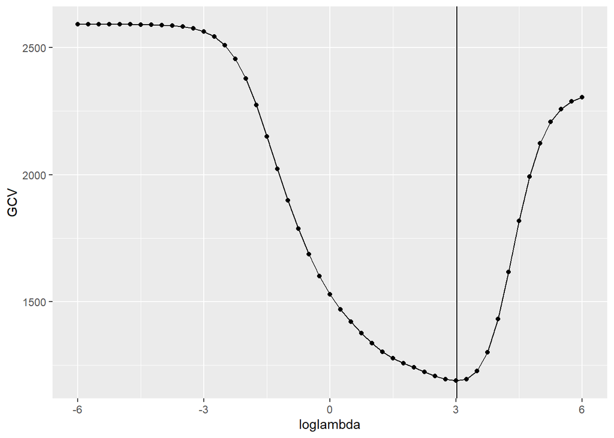

```
## [1] "done"
```

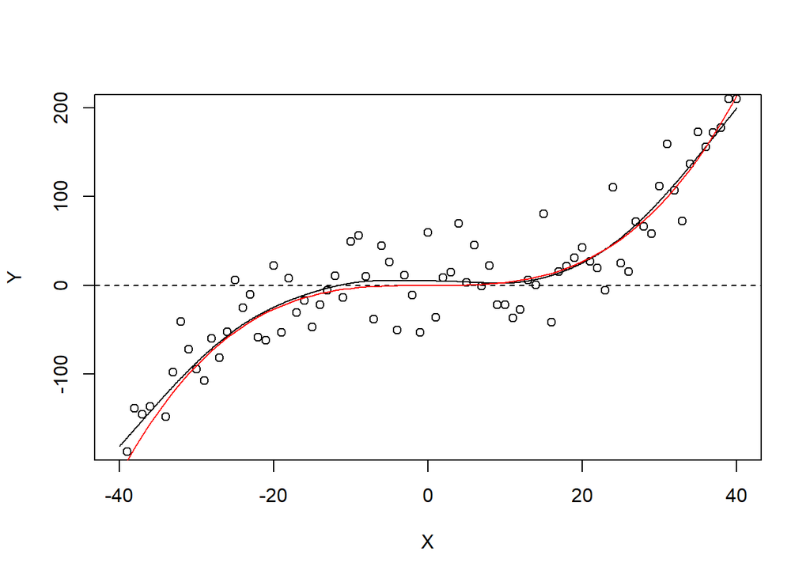

```
##
##  Shapiro-Wilk normality test
##
## data:  residuals
## W = 0.98441, p-value = 0.4319
```

# 5 Appendix

## 5.1 Derivation of A Second Order B-Spline Basis

Say we wish to find a series of B-Spline basis functions of order two and our *knot vector* $U=\{0,1,3,4\}$. Let us first define a B-spline basis of order 1 for the knot vector. This basis would be defined given by the functions:

$$N_{0,1}(x) =
\begin{cases}
1 & if \; \;x \in [0,1)\\
0 & elsewhere
\end{cases}$$
$$N_{1,1}(x) =
\begin{cases}
1 & if \; \;x \in [1,3)\\
0 & elsewhere
\end{cases}$$
$$N_{2,1}(x) =
\begin{cases}
1 & if \; \;x \in [3,4)\\
0 & elsewhere
\end{cases}$$

These functions are shown graphically in Figure 5.1 below:

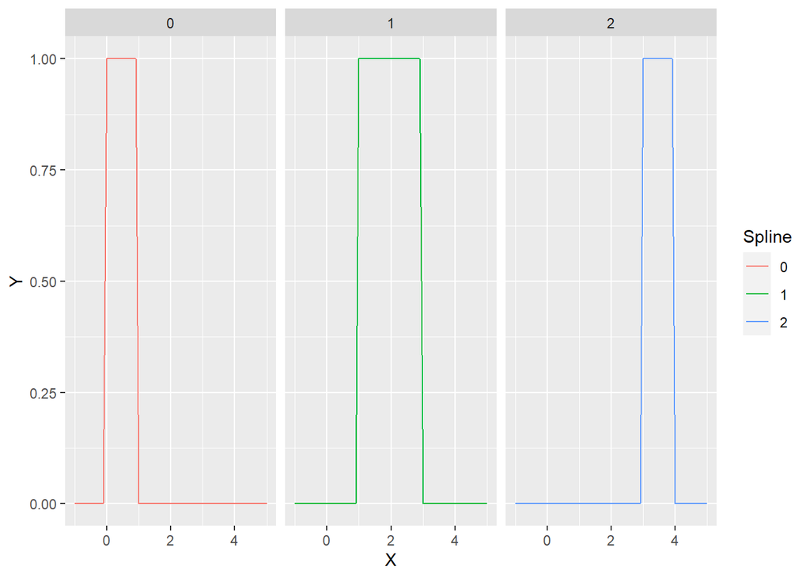

Figure 5.1: 1st Order B-Splines Represented Graphically

$$\omega_{1,2}(x) =
\begin{cases}
\frac{x-t_1}{t_{2}-t_1} & where \; \;t_{2} \neq t_1 \; and \; t_{2} \in U\\
0 & elsewhere
\end{cases}$$

$$\omega_{1,1}(x) = \frac{x-1}{3-1}=\frac{1}{2}x-\frac{1}{2}$$
Using the same method we find that:
$$\omega_{2,1}(x) = x-3$$

Therefore, using the recursion relation:

$$\begin{align*}
N_{1,2}(x) & = \omega_{1,1}(x)N_{1,1}(x)+(1-\omega_{2,1}(x))N_{2,1}(x) \\
& = \left(\frac{1}{2}x-\frac{1}{2}\right)N_{1,1}(x)+(4-x)N_{2,1}(x)
\end{align*}$$

$$\Rightarrow
N_{1,2}(x)=
\begin{cases}
\frac{1}{2}x-\frac{1}{2} & if \; \;x \in [1,3)\\
4-x & if \; \;x \in [3,4)\\
0 & elsewhere
\end{cases}$$

$$N_{-1,2}(x)=
\begin{cases}
1-x & if \; \;x \in [0,1)\\
0 & elsewhere
\end{cases}$$

$$N_{0,2}(x)=
\begin{cases}
x & if \; \;x \in [0,1)\\
\frac{3}{2}-\frac{1}{2}x & if \; \;x \in [1,3)\\
0 & elsewhere
\end{cases}$$

Graphical representation of these functions is given below in Figure 5.2:

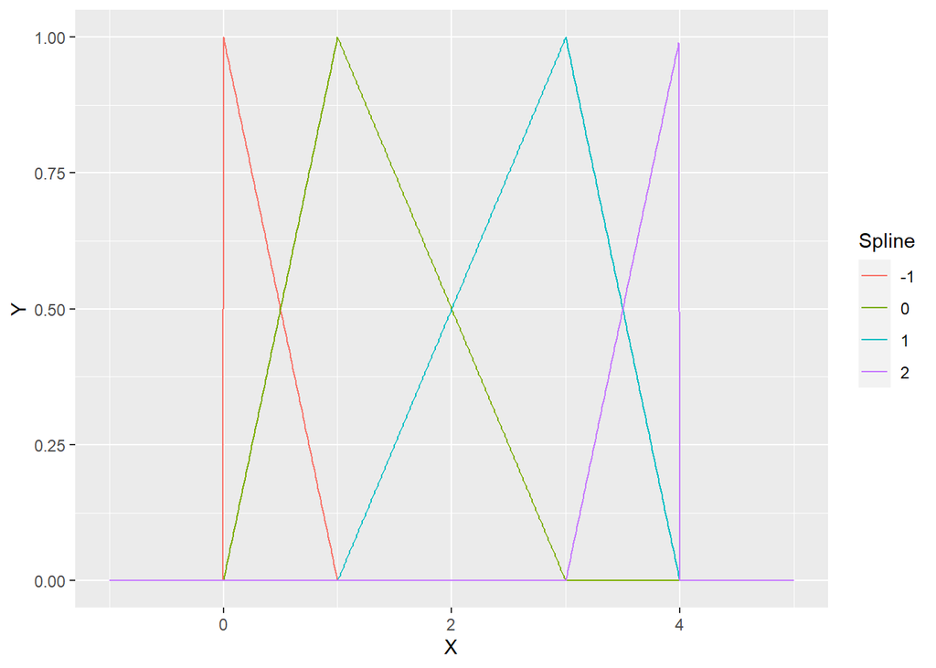

Figure 5.2: 2nd Order B-Spline Functions Represented Graphically

# References

Riccio, Donato. 2022. “Functional Data Analysis: A Solution to the Curse of Dimensionality.” *Toward Data Science*. https://towardsdatascience.com/functional-data-analysis-a-solution-to-the-curse-of-dimensionality-f83dd19fa6e8.